# statistics

*solution_03_central_limit_theorem/02_normal/08_x_from_rightarea_v3*

First, draw a sketch. We can label the $F$ axis by adding integer multiples of 0.5 to 2.1. We know to shade the right because high values of $F$ satisfy the condition $F>f$ (regardless of the exact value of $f$). We don’t know exactly where to place the boundary, but we know the right area is 0.83.

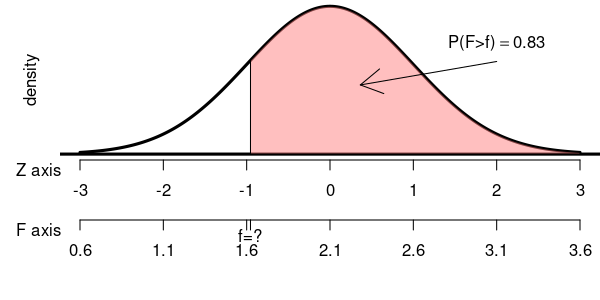

We know how to find the left area.
$$\begin{aligned}
P(F<f) &= 1-P(F>f) \\
&= 1-0.83 \\
&= 0.17
\end{aligned}$$

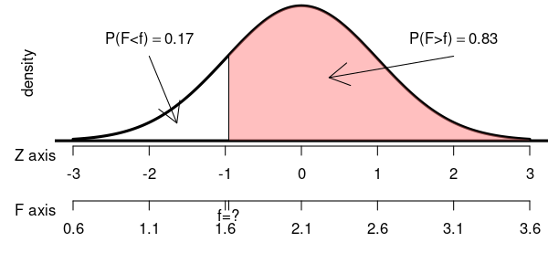

As an intermediate step, we find $z$ such that $P(Z<z)=0.17$.

By using the $z$ table we can determine $z$.

[output not shown]

Either -0.96 or -0.95 is a good estimation of $z$, and either value will lead you to an acceptable answer. Using other tools, a more accurate value can be found. I will show the work with a more accurate value.
$$z=-0.9542$$

We now convert the $z$ score into a $f$ score.
$$\begin{aligned}
f &= \mu+z\sigma \\
&= 2.1+(-0.9542)(0.5) \\
&= 1.623
\end{aligned}$$

We can also visualize this with a spinner.

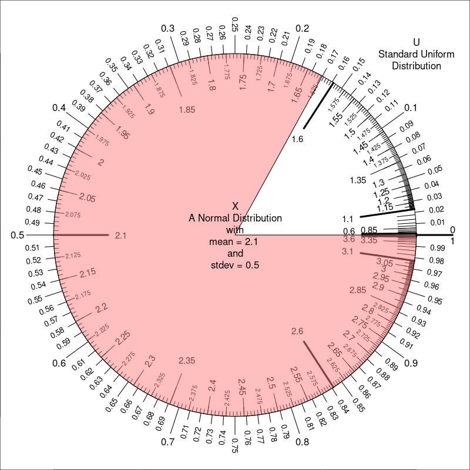

The tolerance for an acceptable answer was $\pm 0.1$ from 1.6229174. So, anything between 1.5229174 and 1.7229174 was accepted.